# Transporting Experimental Estimates Under Unobserved Confounding and Unobserved Effect Modification: Identification, Estimation, and Sensitivity Analysis

Santiago Jiménez Londoño — Universidad EAFIT

June 10, 2026

Abstract

# 1 Introduction

## 1.1 Relevance of the problem

Education research has converged on the randomized controlled trial (RCT) as the benchmark design for evaluating interventions — tutoring programs, curricular reforms, teacher coaching, ed-tech deployments. Randomization solves the problem of *internal validity*: within the experimental sample, the difference in mean outcomes between treated and control arms is unbiased for the average treatment effect (ATE) *in that sample*, regardless of how many confounders remain unmeasured and regardless of how heterogeneous the treatment effect is.

The policy question, however, is almost never about the experimental sample. A ministry of education that funds a tutoring RCT in a convenience sample of urban schools wants to know the effect of *scaling the program to the national school system*. The experimental sample is volunteered, screened, and monitored; the target population is not. When treatment effects are heterogeneous in variables whose distribution differs between the trial and the target — student motivation, school managerial capacity, baseline instructional quality — the trial ATE and the target ATE are different parameters. This is the problem of *external validity*, or in the terminology of Pearl and Bareinboim (2014), *transportability*.

The methodological tension this paper addresses is the following asymmetry, which is well known informally but is rarely stated with full precision:

1. **Internal validity is robust.** Randomization delivers identification of the trial ATE under *no* assumptions about unobserved confounders $U$ or unobserved effect modifiers $V$. Both are balanced (in distribution) across arms by design; $V$ is simply averaged at its trial-population distribution.
2. **External validity is fragile.** The target ATE depends on the distribution of effect modifiers in the target population. If a modifier $V$ is unobserved and its distribution differs across populations, the target ATE is *not identified* from the trial data plus covariate data on the target — and we prove this constructively, not merely by failure of a sufficient condition.

The contribution is then constructive. We characterize assumptions under which transport succeeds *while remaining agnostic about both nuisances*: unobserved confounders of treatment uptake in the target population are irrelevant (because identification routes through the experiment, never through the target’s observational treatment assignment), and unobserved effect modifiers are tolerated provided they are conditionally independent of population membership given an observed covariate vector $W$ — equivalently, provided $W$ *d*-separates the selection node from the modifiers in the selection diagram. We make three further points that matter in practice:

- The identifying assumption can be weakened from full conditional exchangeability of potential outcomes over populations to an assumption on the *mean-difference scale only* (transportability of the conditional ATE), which is strictly weaker and is the actual requirement.
- The resulting functional admits an inverse-odds-of-participation weighting representation and an augmented (AIPW-type) estimator that is consistent if *either* the participation model *or* the trial outcome model is correctly specified.
- When the key assumption fails, the bias has an exact representation as the target-averaged covariance between the conditional effect surface and the shift in the conditional modifier law; this yields a transparent sensitivity bound of the form $\lambda \cdot \rho$ (Lipschitz constant of the effect in the modifier, times an average Wasserstein distance between conditional modifier distributions).

The identification results connect to a literature spanning epidemiology and econometrics — Cole and Stuart (2010), Stuart, Cole, Bradshaw and Leaf (2011), Hotz, Imbens and Mortimer (2005), Dahabreh, Robertson, Tchetgen Tchetgen, Stuart and Hernán (2019), Pearl and Bareinboim (2014), Bareinboim and Pearl (2016). Relative to that literature, the emphasis here is on (a) the precise logical asymmetry between internal and external validity in the presence of the two unobserved nuisances, (b) the mean-scale weakening of the transport assumption, and (c) a sensitivity analysis with an interpretable Lipschitz–Wasserstein structure.

# 2 Setup, Notation, and Graphs

## 2.1 Populations, sampling, and potential outcomes

Let $(\Omega, \mathcal{F}, P)$ support an i.i.d. sample of units $i = 1, \dots, n$ drawn from a *super-population* that mixes two populations indexed by $S_i \in \{0, 1\}$:

- $S_i = 1$: the **trial population** (units eligible and enrolled in the RCT);
- $S_i = 0$: the **target population** (units to which the policy would be scaled).

For each unit define a binary treatment $A_i \in \{0,1\}$, potential outcomes $\big(Y_i(0), Y_i(1)\big)$, an observed pre-treatment covariate vector $W_i \in \mathcal{W} \subseteq \mathbb{R}^{d}$, an **unobserved effect modifier** $V_i \in \mathcal{V} \subseteq \mathbb{R}$, and an **unobserved confounder** $U_i \in \mathbb{R}$. The observed outcome is $Y_i = Y_i(A_i)$ under consistency (Assumption A1 below). In the trial, treatment is assigned by a known randomization device; in the target population treatment uptake (if observed at all) is *self-selected* and may depend arbitrarily on $U_i$, which also affects outcomes.

The conditional average treatment effect (CATE) surface is
$$\tau(w, v) \;=\; \mathbb{E}\big[\,Y(1) - Y(0)\,\big|\, W = w,\; V =
v\,\big],$$
and the two population-level estimands are
$$\tau_1 \;=\; \mathbb{E}\big[Y(1) - Y(0)\,\big|\,S = 1\big]
\qquad\text{(trial ATE, internal validity)},$$
$$\tau_0 \;=\; \mathbb{E}\big[Y(1) - Y(0)\,\big|\,S = 0\big]
\qquad\text{(target ATE, external validity)}.$$

**Observed data.** The analyst observes $O_i = \big(S_i,\; W_i,\; S_i A_i,\; S_i Y_i,\; (1-S_i) A_i^{obs},\; (1-S_i) Y_i^{obs}\big)$: full experimental data in the trial, covariates in the target, and possibly observational (confounded) treatment–outcome data in the target. Neither $V_i$ nor $U_i$ is ever observed in either population.

## 2.2 Selection diagrams

Following Pearl and Bareinboim (2014), we encode cross-population structure with a *selection diagram*: a causal DAG over $(W, V, U, A, Y)$ augmented with a selection node $S$ whose children are exactly the variables whose mechanisms (or exogenous distributions) may differ between the two populations. The two regimes we study are drawn below in the Simulation section’s graphics device; their structure is:

**Diagram $\mathcal{G}_1$ (transportable case).** $W \to V$, $V \to Y$, $W \to Y$, $U \to Y$, $A \to Y$, and $S \to W$ (populations differ in the law of $W$, hence — only *through* $W$ — in the law of $V$). In the trial regime, $A$ has no parents (randomization); in the target’s observational regime, $U \to A$. The crucial feature is the **absence of an edge $S \to V$ except through $W$**: conditioning on $W$ *d*-separates $S$ from $V$, i.e. $V \perp\!\!\!\perp S \mid W$.

**Diagram $\mathcal{G}_2$ (non-transportable case).** Identical, except $S \to V$ directly: populations differ in the conditional law of the modifier given $W$. Then $V \not\perp\!\!\!\perp S \mid W$ and, as Proposition 2 shows, $\tau_0$ is not identified.

Two readings of the diagrams are worth fixing now. First, $U \to A$ in the target regime makes the target’s observational contrast $\mathbb{E}[Y \mid A=1, S=0] - \mathbb{E}[Y \mid A=0, S=0]$ confounded: the back-door path $A \leftarrow U \to Y$ is open. Second, the path $S \to W \to V \to Y$ (and $S \to W \to Y$) makes the *trial* contrast a biased answer to the *target* question: $S$ and the effect surface share ancestors. Internal validity requires blocking the first phenomenon (randomization does it by surgery on $A$); external validity requires blocking the second (no design can do it; only an assumption on $S$’s children can).

# 3 Internal Validity Under Unobserved Confounders and Effect Modifiers

# 4 The Failure of External Validity

## 4.2 Constructive non-identification

# 5 Identification: Assumptions and the Transport Formula

## 5.1 Assumptions

The strategy is to be maximally permissive about $U$ and $V$ and place the identifying restriction on the *relationship between the unobservables and population membership*, conditional on what is observed.

## 5.3 Estimation: plug-in, weighting, and a doubly robust estimator

Let $\widehat{e}(w)$ be an estimator of the participation score (e.g. logistic regression of $S$ on $W$ on the pooled sample), $\widehat{\omega} = (1-\widehat{e})/\widehat{e}$, and $\widehat{\mu}_a(w)$ an estimator of the trial outcome regression. With $n_0 = \sum_i (1 - S_i)$, define:

**(i) Outcome-model (g-formula) estimator**
$$\widehat{\tau}_0^{\,om}
= \frac{1}{n_0} \sum_{i: S_i = 0}
\big\{ \widehat{\mu}_1(W_i) - \widehat{\mu}_0(W_i) \big\}.$$

**(ii) Inverse-odds weighting (Hájek) estimator**
$$\widehat{\tau}_0^{\,ipw}
= \frac{\sum_{i: S_i=1} \widehat{\omega}(W_i)\, A_i Y_i}
{\sum_{i: S_i=1} \widehat{\omega}(W_i)\, A_i}
\;-\;
\frac{\sum_{i: S_i=1} \widehat{\omega}(W_i)\, (1-A_i) Y_i}
{\sum_{i: S_i=1} \widehat{\omega}(W_i)\, (1-A_i)} .$$

**(iii) Augmented (AIPW) estimator**
$$\widehat{\tau}_0^{\,dr}
= \frac{1}{n\,\widehat{P}(S=0)} \sum_{i=1}^{n}
\left[
(1 - S_i)\,\big\{\widehat{\mu}_1(W_i) - \widehat{\mu}_0(W_i)\big\}
\;+\;
S_i\, \widehat{\omega}(W_i)
\Big( \frac{A_i}{\pi} \,\widehat{R}_{1i} - \frac{1-A_i}{1-\pi}\,
\widehat{R}_{0i} \Big)
\right],$$
with residuals $\widehat{R}_{ai} = Y_i - \widehat{\mu}_a(W_i)$. This is the sample analogue of the (uncentered) efficient influence function for $\tau_0$ in this model (cf. Dahabreh et al., 2019).

## 5.4 Sensitivity analysis for violations of A4

Suppose A4 fails. Define the *transport gap*
$$\delta(w) \;=\;
\mathbb{E}\big[Y(1)-Y(0) \mid W=w, S=0\big]
-
\mathbb{E}\big[Y(1)-Y(0) \mid W=w, S=1\big],$$
so that, exactly,

$$\begin{equation}
\begin{aligned}
\tau_0
&=
\underbrace{
\mathbb{E}\big[\tau(W)\mid S=0\big]
}_{\text{identified target of } \widehat{\tau}_0}
+
\underbrace{
\mathbb{E}\big[\delta(W)\mid S=0\big]
}_{\text{bias}} .
\end{aligned}
\label{eq:bias-decomposition}
\end{equation}$$

# 6 Simulation

The design mimics an education scale-up: a tutoring program is evaluated in an RCT whose schools are recruited disproportionately from high-baseline contexts ($W$, observed: baseline achievement / SES index), the effect is larger for more motivated students ($V$, unobserved, correlated with $W$), and in the target population uptake of comparable programs is driven by unobserved family resources ($U$), which also raise outcomes — a textbook confounder.

## 6.1 Data-generating process

With $\Phi$-independent standard normal shocks,
$$W \sim \mathcal{N}(0,1), \quad
V = 0.8\,W + \varepsilon_V, \quad
U \sim \mathcal{N}(0,1), \quad
P(S=1 \mid W) = \mathrm{logit}^{-1}(-0.5 + 1.2\,W),$$
$$A \mid S=1 \sim \mathrm{Bern}(0.5), \qquad
A \mid S=0 = \mathbf{1}\{0.8\,U + \nu > 0\},$$
$$Y = 1 + \tau_a A + \tau_v\, A V + 0.5\,W + 0.8\,U + \varepsilon_Y,
\qquad (\tau_a, \tau_v) = (1,\ 0.5).$$
Note the three structural facts the theory predicts: (a) $V \perp\!\!\!\perp S \mid W$ holds by construction (selection depends on $W$ and independent noise only), so A4 holds; (b) $U$ confounds the target’s observational contrast; (c) $\mathbb{E}[V \mid S=1] > \mathbb{E}[V \mid S=0]$, so $\tau_1 > \tau_0$.

```r
expit <- function(x) 1 / (1 + exp(-x))
tau_a <- 1.0; tau_v <- 0.5

draw <- function(n, violate = FALSE, seed = NULL) {
  if (!is.null(seed)) set.seed(seed)
  W   <- rnorm(n)
  V   <- 0.8 * W + rnorm(n)                       # unobserved effect modifier
  U   <- rnorm(n)                                 # unobserved confounder
  pS  <- if (violate) expit(-0.5 + 0.8 * W + 1.0 * V)   # A4 violated: S <- V
         else         expit(-0.5 + 1.2 * W)             # A4 holds:    S <- W only
  S   <- rbinom(n, 1, pS)
  A   <- ifelse(S == 1,
                rbinom(n, 1, 0.5),                # randomized in the trial
                as.integer(0.8 * U + rnorm(n) > 0))  # confounded uptake in target
  Y   <- 1 + tau_a * A + tau_v * A * V + 0.5 * W + 0.8 * U + rnorm(n)
  data.frame(W, V, U, S, A, Y)
}

## Ground truth by large Monte Carlo
big <- draw(4e6, violate = FALSE, seed = 1)
tau1_true <- tau_a + tau_v * mean(big$V[big$S == 1])
tau0_true <- tau_a + tau_v * mean(big$V[big$S == 0])
c(tau1_true = round(tau1_true, 3), tau0_true = round(tau0_true, 3))
```

```
## tau1_true tau0_true
##     1.224     0.849
```

The trial ATE ($\approx 1.22$) and the target ATE ($\approx 0.85$) differ by roughly 0.37 — about 44% of the target effect. Reporting the internally valid trial estimate as the policy parameter would overstate the scaled-up effect by nearly half.

## 6.2 Selection diagrams

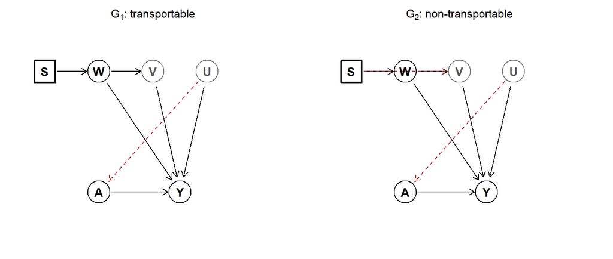

```r
draw_dag <- function(nodes, edges, title) {
  plot.new()
  plot.window(xlim = c(0, 10), ylim = c(0, 6))

  for (e in edges) {
    p1 <- nodes[[e[1]]]
    p2 <- nodes[[e[2]]]

    is_dashed <- length(e) >= 3 && identical(e[3], "d")

    d <- p2 - p1
    d <- d / sqrt(sum(d^2))

    a <- p1 + 0.45 * d
    b <- p2 - 0.45 * d

    arrows(
      a[1], a[2], b[1], b[2],
      length = 0.09,
      lty = if (is_dashed) 2 else 1,
      col = if (is_dashed) "firebrick" else "black"
    )
  }

  for (nm in names(nodes)) {
    p <- nodes[[nm]]
    unobs <- nm %in% c("U", "V")
    sel <- nm == "S"

    if (sel) {
      rect(p[1] - .38, p[2] - .32, p[1] + .38, p[2] + .32, lwd = 2)
    } else {
      symbols(
        p[1], p[2],
        circles = .42,
        inches = FALSE,
        add = TRUE,
        fg = if (unobs) "gray45" else "black",
        lty = if (unobs) 2 else 1
      )
    }

    text(
      p[1], p[2], nm,
      font = 2,
      col = if (unobs) "gray35" else "black"
    )
  }

  title(main = title, cex.main = .95)
}

nodes <- list(
  S = c(1, 5),
  W = c(3, 5),
  V = c(5, 5),
  U = c(7, 5),
  A = c(3, 1.5),
  Y = c(6, 1.5)
)

op <- par(mfrow = c(1, 2), mar = c(.5, .5, 2, .5))

draw_dag(
  nodes,
  list(
    c("S","W"), c("W","V"), c("V","Y"), c("W","Y"),
    c("U","Y"), c("A","Y"), c("U","A","d")
  ),
  expression(G[1]*": transportable")
)

draw_dag(
  nodes,
  list(
    c("S","W"), c("W","V"), c("V","Y"), c("W","Y"),
    c("U","Y"), c("A","Y"), c("U","A","d"), c("S","V","d")
  ),
  expression(G[2]*": non-transportable")
)
```

```r
par(op)
```

Square node: selection indicator. Dashed gray circles: unobserved variables. The dashed red edge $U \to A$ is present only in the target’s observational regime (it is severed by randomization when $S=1$). In $\mathcal{G}_1$, conditioning on $W$ blocks every path from $S$ to $V$, so $V \perp\!\!\!\perp S \mid W$ and A4 holds; in $\mathcal{G}_2$ the direct edge $S \to V$ keeps $S$ and $V$ dependent given $W$ and identification fails.

## 6.3 Estimators

```r
estimate_all <- function(d) {
  tr <- d[d$S == 1, ]; tg <- d[d$S == 0, ]

  ## (0) internally valid trial estimate; naive observational target estimate
  dm_trial <- mean(tr$Y[tr$A == 1]) - mean(tr$Y[tr$A == 0])
  dm_obs   <- mean(tg$Y[tg$A == 1]) - mean(tg$Y[tg$A == 0])

  ## participation score and inverse-odds weights (pooled logistic in W)
  ps  <- glm(S ~ W, family = binomial, data = d)
  ehat <- predict(ps, type = "response")
  w    <- (1 - ehat) / ehat
  wt   <- w[d$S == 1]

  ## (i) IPW (Hajek) transported estimator
  ipw <- with(tr, sum(wt * A * Y) / sum(wt * A) -
                  sum(wt * (1 - A) * Y) / sum(wt * (1 - A)))

  ## (ii) outcome-model (g-formula) estimator: trial regression Y ~ A*W
  om_fit <- lm(Y ~ A * W, data = tr)
  cf  <- coef(om_fit)
  om  <- mean(cf["A"] + cf["A:W"] * tg$W)

  ## (iii) AIPW (doubly robust)
  m1 <- cf["(Intercept)"] + cf["A"] + (cf["W"] + cf["A:W"]) * d$W
  m0 <- cf["(Intercept)"] + cf["W"] * d$W
  p0 <- mean(d$S == 0)
  dr <- mean((1 - d$S) * (m1 - m0) / p0 +
             d$S * w * ((d$A / 0.5) * (d$Y - m1) -
                        ((1 - d$A) / 0.5) * (d$Y - m0)) / p0)

  c(trial_DM = dm_trial, target_obs_DM = dm_obs,
    IPW = ipw, OM = om, AIPW = dr)
}
```

## 6.4 Monte Carlo: A4 holds

```r
R <- 300; n <- 20000
res <- t(sapply(seq_len(R), function(s) estimate_all(draw(n, FALSE, seed = s))))
tab <- rbind(`MC mean` = colMeans(res),
             `MC sd`   = apply(res, 2, sd),
             `Bias vs tau0` = colMeans(res) - tau0_true)
knitr::kable(round(tab, 3), caption = paste0(
  "300 replications, n = 20,000. True tau1 = ", round(tau1_true, 3),
  "; true tau0 = ", round(tau0_true, 3), "."))
```

300 replications, n = 20,000. True tau1 = 1.224; true tau0 = 0.849.

|  | trial_DM | target_obs_DM | IPW | OM | AIPW |
| --- | --- | --- | --- | --- | --- |
| MC mean | 1.221 | 1.649 | 0.846 | 0.844 | 0.845 |
| MC sd | 0.031 | 0.025 | 0.066 | 0.043 | 0.051 |
| Bias vs tau0 | 0.372 | 0.800 | -0.003 | -0.005 | -0.004 |

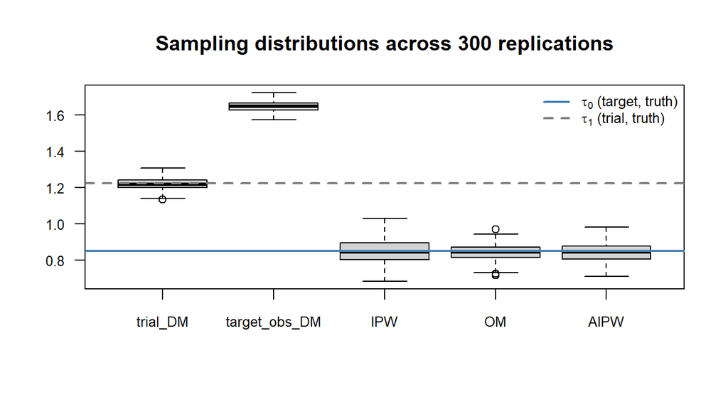

```r
boxplot(res, las = 1, cex.axis = .8,
        main = "Sampling distributions across 300 replications")
abline(h = tau0_true, lwd = 2, col = "steelblue")
abline(h = tau1_true, lwd = 2, lty = 2, col = "gray50")
legend("topright", bty = "n", cex = .8, lwd = 2, lty = c(1, 2),
       col = c("steelblue", "gray50"),
       legend = c(expression(tau[0]~"(target, truth)"),
                  expression(tau[1]~"(trial, truth)")))
```

The pattern is exactly the theory. The trial difference-in-means is unbiased for $\tau_1$ — Theorem 1 in action, untouched by $U$ and $V$ — but misses $\tau_0$ by the full heterogeneity gap. The naive observational contrast in the target is even worse: it adds confounding bias from $U$ on top. All three transported estimators (IPW, OM, AIPW) are centered on $\tau_0$, despite never observing $V$ or $U$, because A4 holds: $W$ absorbs the entire cross-population shift in the modifier’s distribution.

## 6.5 Double robustness

```r
aipw_misspec <- function(d, bad_om = FALSE, bad_e = FALSE) {
  tr <- d[d$S == 1, ]
  ehat <- if (bad_e) rep(mean(d$S), nrow(d))         # wrong: constant score
          else predict(glm(S ~ W, binomial, data = d), type = "response")
  w <- (1 - ehat) / ehat
  cf <- if (bad_om) c(coef(lm(Y ~ A, data = tr)), W = 0, `A:W` = 0)  # wrong: no W
        else coef(lm(Y ~ A * W, data = tr))
  m1 <- cf[1] + cf["A"] + (cf["W"] + cf["A:W"]) * d$W
  m0 <- cf[1] + cf["W"] * d$W
  p0 <- mean(d$S == 0)
  mean((1 - d$S) * (m1 - m0) / p0 +
       d$S * w * ((d$A / .5) * (d$Y - m1) -
                  ((1 - d$A) / .5) * (d$Y - m0)) / p0)
}
dr_tab <- t(sapply(seq_len(R), function(s) {
  d <- draw(n, FALSE, seed = s)
  c(`wrong OM, correct e` = aipw_misspec(d, bad_om = TRUE),
    `correct OM, wrong e` = aipw_misspec(d, bad_e  = TRUE),
    `both wrong`          = aipw_misspec(d, TRUE, TRUE))
}))
knitr::kable(round(rbind(`MC mean` = colMeans(dr_tab),
                         `Bias vs tau0` = colMeans(dr_tab) - tau0_true), 3),
             caption = "AIPW under nuisance misspecification (300 reps).")
```

AIPW under nuisance misspecification (300 reps).

|  | wrong OM, correct e | correct OM, wrong e | both wrong |
| --- | --- | --- | --- |
| MC mean | 0.845 | 0.844 | 1.221 |
| Bias vs tau0 | -0.004 | -0.005 | 0.372 |

Consistent under either correct nuisance, biased only when both fail — Proposition 3 verified. (With both nuisances wrong, the estimator collapses to the unweighted trial contrast and recovers $\tau_1$, the predicted failure mode.)

## 6.6 Violation of A4 and the sensitivity bound

We now let selection depend on $V$ directly given $W$ ($\mathcal{G}_2$): $P(S=1 \mid W, V) = \mathrm{logit}^{-1}(-0.5 + 0.8W + V)$.

```r
bigv <- draw(4e6, violate = TRUE, seed = 2)
tau0_v <- tau_a + tau_v * mean(bigv$V[bigv$S == 0])

resv <- t(sapply(seq_len(R), function(s) estimate_all(draw(n, TRUE, seed = s))))
knitr::kable(round(rbind(`MC mean` = colMeans(resv),
                         `Bias vs tau0` = colMeans(resv) - tau0_v), 3),
  caption = paste0("A4 violated. True tau0 = ", round(tau0_v, 3), "."))
```

A4 violated. True tau0 = 0.697.

|  | trial_DM | target_obs_DM | IPW | OM | AIPW |
| --- | --- | --- | --- | --- | --- |
| MC mean | 1.414 | 1.496 | 1.134 | 1.121 | 1.127 |
| Bias vs tau0 | 0.717 | 0.799 | 0.437 | 0.424 | 0.430 |

```r
## Oracle ingredients of Proposition 4 (knowable to the simulator, not the analyst):
## lambda = |tau_v| (Lipschitz constant of tau in v);
## rho(w)  = W1 distance between N(mu_s(w), .) conditional laws of V given W;
## for these near-Gaussian conditionals we evaluate rho(w) by within-cell means.
cells <- cut(bigv$W, quantile(bigv$W, 0:50 / 50), include.lowest = TRUE)
m1c <- tapply(bigv$V[bigv$S == 1], cells[bigv$S == 1], mean)
m0c <- tapply(bigv$V[bigv$S == 0], cells[bigv$S == 0], mean)
p0c <- table(cells[bigv$S == 0]) / sum(bigv$S == 0)   # target weights by cell
rho_bar <- sum(abs(m0c - m1c) * p0c)                  # E[rho(W) | S = 0]
bound   <- tau_v * rho_bar

cat(sprintf(
  "Observed |bias| of AIPW: %.3f   Sensitivity bound lambda*rho_bar: %.3f\n",
  abs(mean(resv[, "AIPW"]) - tau0_v), bound))
```

```
## Observed |bias| of AIPW: 0.430   Sensitivity bound lambda*rho_bar: 0.434
```

When A4 fails the transported estimators are biased, as Proposition 2 says they must be — no estimator can do better without further information. But the bias is *covered* by the Lipschitz–Wasserstein bound of Proposition 4: the interval $\widehat\tau_0 \pm \lambda\bar\rho$ contains the true $\tau_0$. In practice $(\lambda, \bar\rho)$ are not oracle quantities; the recommended report is the breakdown frontier — the locus of $(\lambda, \bar\rho)$ pairs at which the policy conclusion (e.g. $\tau_0 > 0$, or $\tau_0$ above a cost-effectiveness threshold) would be overturned.

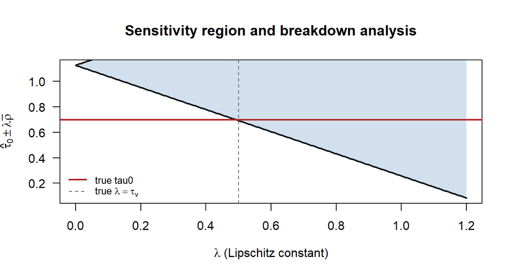

```r
tau_hat <- mean(resv[, "AIPW"])
lam <- seq(0, 1.2, length.out = 200)
plot(lam, tau_hat - lam * rho_bar, type = "l", lwd = 2, las = 1,
     xlab = expression(lambda~"(Lipschitz constant)"),
     ylab = expression(hat(tau)[0] %+-% lambda * bar(rho)),
     main = "Sensitivity region and breakdown analysis")
lines(lam, tau_hat + lam * rho_bar, lwd = 2)
polygon(c(lam, rev(lam)),
        c(tau_hat - lam * rho_bar, rev(tau_hat + lam * rho_bar)),
        col = grDevices::adjustcolor("steelblue", .25), border = NA)
abline(h = 0, lty = 3); abline(h = tau0_v, col = "firebrick", lwd = 2)
abline(v = tau_v, lty = 2, col = "gray40")
legend("bottomleft", bty = "n", cex = .8,
       legend = c("true tau0", expression("true "*lambda == tau[v])),
       col = c("firebrick", "gray40"), lwd = c(2, 1), lty = c(1, 2))
```

# 7 Conclusion

Internal validity is a property of the *design*: randomization closes the back-door through any unobserved confounder and lets unobserved effect modifiers be averaged at the distribution from which the experiment itself samples. External validity is a property of the *population mapping*: it requires integrating the same heterogeneous effect surface against a measure — the target law of the modifiers — about which the data are silent whenever the modifiers are unobserved and differentially distributed. We showed the failure is one of identification (Proposition 2), characterized the minimal repair (A4: the observed covariates must *d*-separate selection from the unobserved modifiers, on the mean-difference scale), derived the transport formula with weighting and doubly robust implementations, and bounded the damage when the repair fails via a Lipschitz–Wasserstein sensitivity analysis. The Monte Carlo evidence matches each claim. The practical prescription for education scale-ups is concrete: measure, in *both* the trial and the target, the covariates that plausibly drive recruitment *and* effect heterogeneity; route identification through the experiment, never through the target’s confounded uptake; and report the breakdown frontier rather than a single transported point estimate.

# 8 References

Bareinboim, E., and J. Pearl (2016): “Causal Inference and the Data-Fusion Problem,” *Proceedings of the National Academy of Sciences*, 113(27), 7345–7352.

Cole, S. R., and E. A. Stuart (2010): “Generalizing Evidence From Randomized Clinical Trials to Target Populations: The ACTG 320 Trial,” *American Journal of Epidemiology*, 172(1), 107–115.

Dahabreh, I. J., S. E. Robertson, E. J. Tchetgen Tchetgen, E. A. Stuart, and M. A. Hernán (2019): “Generalizing Causal Inferences From Individuals in Randomized Trials to All Trial-Eligible Individuals,” *Biometrics*, 75(2), 685–694.

Hernán, M. A., and J. M. Robins (2020): *Causal Inference: What If*. Boca Raton: Chapman & Hall/CRC.

Hotz, V. J., G. W. Imbens, and J. H. Mortimer (2005): “Predicting the Efficacy of Future Training Programs Using Past Experiences at Other Locations,” *Journal of Econometrics*, 125(1–2), 241–270.

Imbens, G. W., and D. B. Rubin (2015): *Causal Inference for Statistics, Social, and Biomedical Sciences: An Introduction*. Cambridge: Cambridge University Press.

Pearl, J., and E. Bareinboim (2014): “External Validity: From Do-Calculus to Transportability Across Populations,” *Statistical Science*, 29(4), 579–595.

Rosenbaum, P. R., and D. B. Rubin (1983): “The Central Role of the Propensity Score in Observational Studies for Causal Effects,” *Biometrika*, 70(1), 41–55.

Rubin, D. B. (1974): “Estimating Causal Effects of Treatments in Randomized and Nonrandomized Studies,” *Journal of Educational Psychology*, 66(5), 688–701.

Stuart, E. A., S. R. Cole, C. P. Bradshaw, and P. J. Leaf (2011): “The Use of Propensity Scores to Assess the Generalizability of Results From Randomized Trials,” *Journal of the Royal Statistical Society: Series A*, 174(2), 369–386.